# Homework1

Haodong Yan

2022-10-10

Question 1:

Define supervised and unsupervised learning. What are the difference(s) between them?

In supervised learning, for each observation of the predictor measurement(s) xi, i = 1,…,n there is an associated response measurement $y_i$, which is to train the model with labelled data. Unsupervised learning has no associated response measurement $y_i$, meaning to have models trained on raw and unlabeled training data. The main difference is the need for labelled training data.

Question 2:

Explain the difference between a regression model and a classification model, specifically in the context of machine learning.

A regression model has numerical values such as price and blood pressure as response variable, the result is quantitative. For classification model, they make predictions on categorical values such as whether a person is survived or died, whether an object is or is not a spam, the result is qualitative.

Question 3:

Name two commonly used metrics for regression ML problems. Name two commonly used metrics for classification ML problems.

Mean Squared Error and Mean Absolute Error are two commonly used metrics for regression ML problems;

Confusion Matrix and Receiver Operating Characteristic curve are two commonly used metrics for classification ML problems.

Question 4: As discussed, statistical models can be used for different purposes. These purposes can generally be classified into the following three categories. Provide a brief description of each.

Descriptive models: Visually emphasize a trend or trends in data

Inferential models: Make inferences about the relationship between predictor and response.

Predictive models: Predicting the outcome variable as accurately as possible and minimize reducible error.

Question 5: Predictive models are frequently used in machine learning, and they can usually be described as either mechanistic or empirically-driven. Answer the following questions.

Define mechanistic. Define empirically-driven. How do these model types differ? How are they similar?

Mechanistic models assume a parametric form for the relationship between the predictors and the response. They tend to have high bias and low variance. Empirically-driven models make little assumptions about the form of the relationship. They tend to have high variance and low bias

In general, is a mechanistic or empirically-driven model easier to understand? Explain your choice.

In general, mechanistic models are easier to understand, since it is easier to estimate a set of parameters in a linear model.

Describe how the bias-variance trade off is related to the use of mechanistic or empirically-driven models.

Mechanistic models have higher bias and lower variance and empirically-driven models have higher variance and lower bias.

Question 6: A political candidate’s campaign has collected some detailed voter history data from their constituents. The campaign is interested in two questions:

Given a voter’s profile/data, how likely is it that they will vote in favor of the candidate?

How would a voter’s likelihood of support for the candidate change if they had personal contact with the candidate?

Classify each question as either predictive or inferential. Explain your reasoning for each.

1. Predictive, it aims predict the result of the voter’s background
2. Inferential, it aims to test a theory and talks about the relationship between predictor and the outcome.

Exploratory Data Analysis

Exercise 1: We are interested in highway miles per gallon, or the hwy variable. Create a histogram of this variable. Describe what you see/learn.

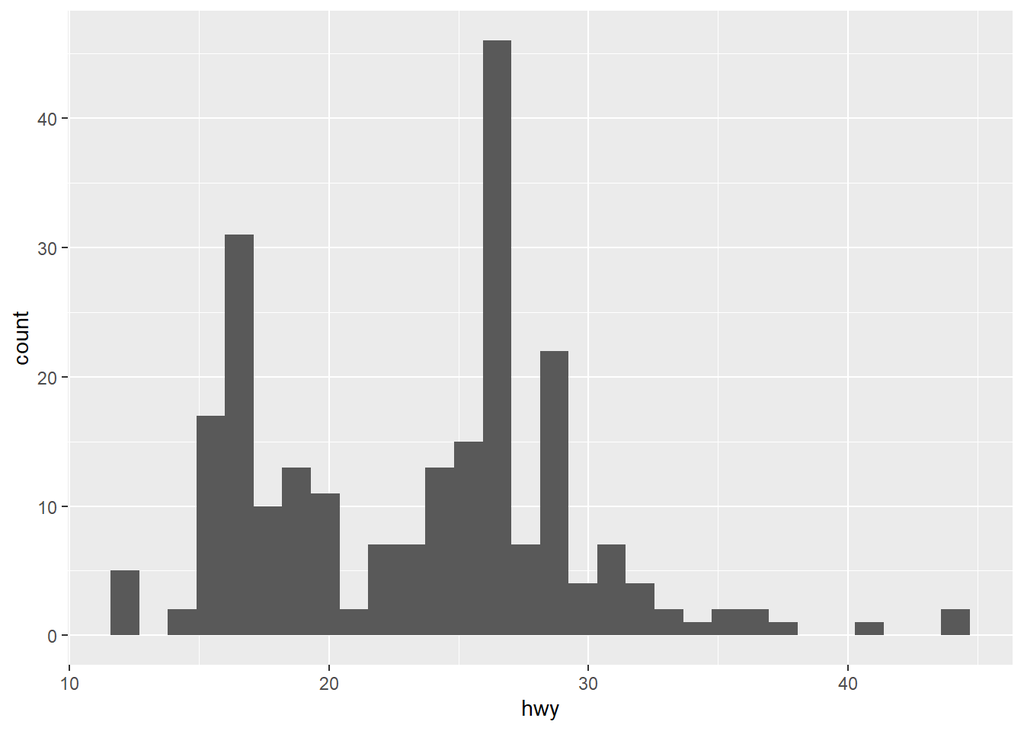

```r
mpg %>% ggplot(aes(x = hwy)) + geom_histogram()
```

The graph for highway miles per gallon is skewed to the right. Most observations are concentrated from 15 mpg to 27 mpg. There ar e two peaks in the observation, one located at 16-17 mpg, the other one located at 26-27 mpg.

Exercise 2: Create a scatterplot. Put hwy on the x-axis and cty on the y-axis. Describe what you notice. Is there a relationship between hwy and cty? What does this mean?

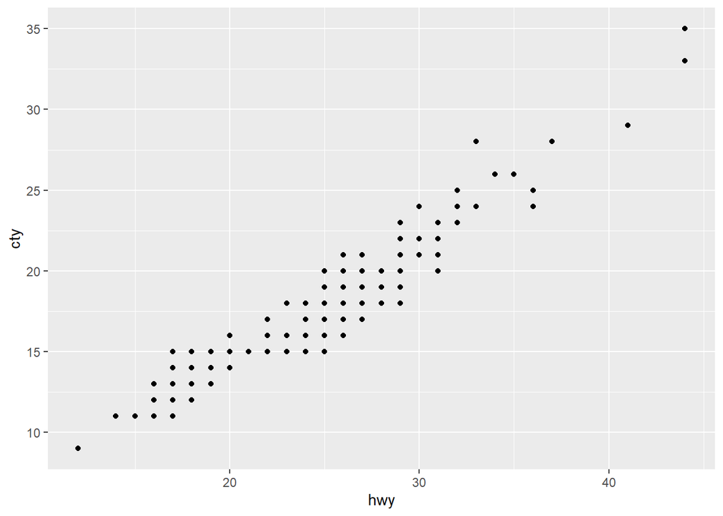

```r
mpg %>% ggplot(aes(x = hwy, y = cty)) + geom_point()
```

There is a positive correlation between hwy and cty. This means the higher hwy is the higher cty will be.

Exercise 3: Make a bar plot of manufacturer. Flip it so that the manufacturers are on the y-axis. Order the bars by height. Which manufacturer produced the most cars? Which produced the least?

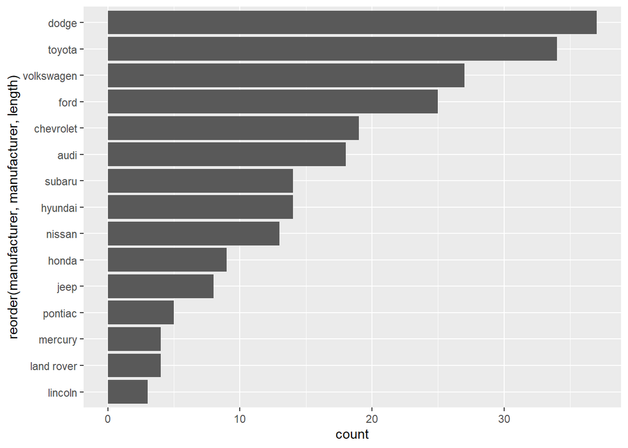

```r
mpg %>% ggplot( aes(x = reorder(manufacturer, manufacturer, length))) + geom_bar() + coord_flip()
```

Dodge produced the most cars, Lincoln produced the least.

Exercise 4: Make a box plot of hwy, grouped by cyl. Do you see a pattern? If so, what?

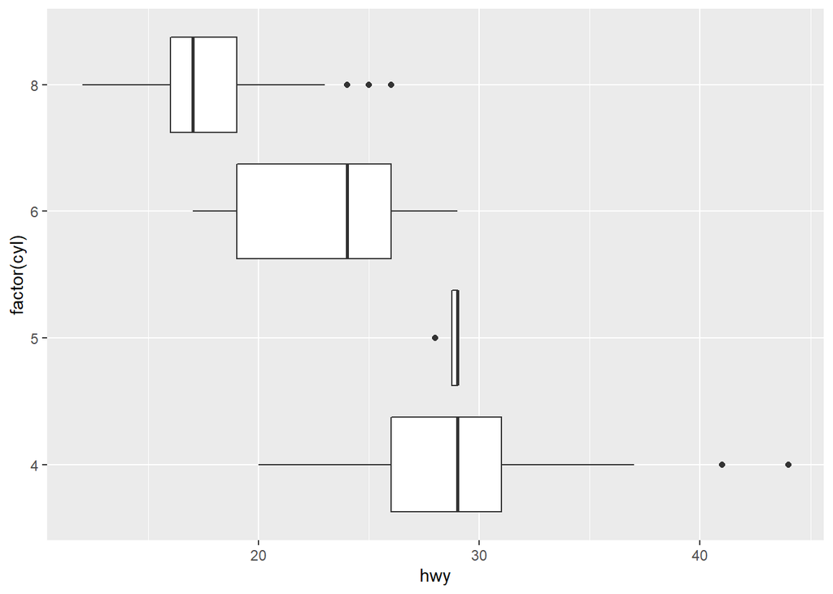

```r
mpg %>% ggplot(aes(x = hwy, y = factor(cyl)))+geom_boxplot()
```

The highway mileage tends to increase when cyl decreases.

Exercise 5: Use the corrplot package to make a lower triangle correlation matrix of the mpg dataset. (Hint: You can find information on the package here.)

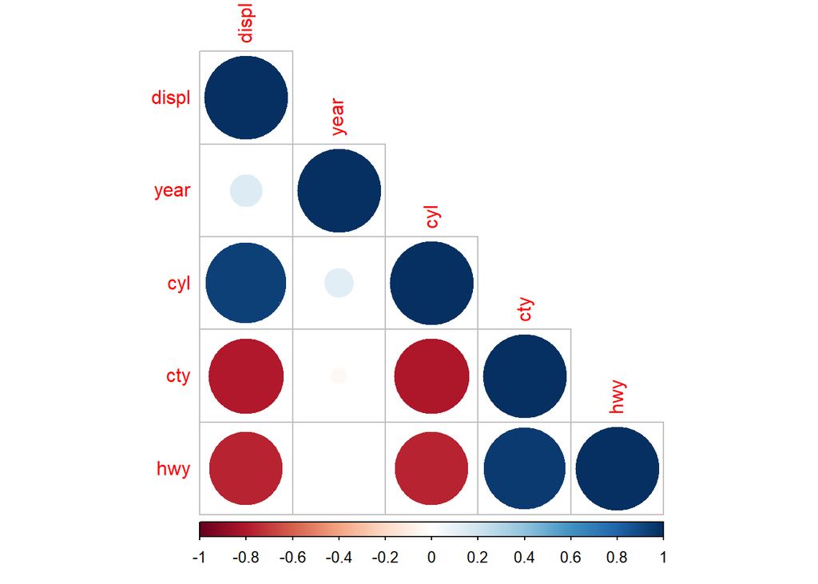

```r
select(mpg, is.numeric) %>% cor() %>% corrplot( type = "lower")
```

Which variables are positively or negatively correlated with which others? Do these relationships make sense to you? Are there any that surprise you?

displ is positively correlated with cyl,hwy is positively correlated with cty. Year and displ has a weak positive correlation. Year and cyl has a weak positive correlation. cty and displ has a negative correlation. hwy and displ has a negative correlation. cty and cyl has a negative correlation as well as hwy and cyl. They makes sense to me.